## 数据挖掘第一次课程作业

#### 吴嘉豪 _3220190894_

## 数据预处理

### 1. python库引入

引入需要使用的库函数 ：

```python
import numpy as np
import matplotlib.pyplot as plt
import pandas as pd
import re
import datetime
import random
from sklearn.linear_model import LinearRegression

%matplotlib inline
plt.rcParams['font.sans-serif']=['SimHei']
plt.rcParams['axes.unicode_minus'] = False
```

### 2. 处理数据集 - Oakland Crime Statistics 2011 to 2016

**数据集分析** ： 这是加州Okaland市2011-2016年犯罪率相关的数据，主要文件有11-16六个csv格式数据组成，数据表中记录的属性有Agency \ Create Time \ Locatio \ Area Id \ Beat \ Priority \ Incident Type Id \ Incident Type Description \ Event Number \ Closed Time等，其中部分年份的数据记录中缺失Location属性。

```python
data_dir_oka = r"F:/course/web/data/oakland_crime"
crime_data_dict = {}
for i in range(1,7):
    crime_data = pd.read_csv(data_dir_oka + r"/records-for-201" + str(i) + ".csv")
    crime_data_dict["201" + str(i)] = crime_data
print(crime_data_dict["2011"].head()) # 输出2011年数据作为示例  可见2011年数据有11列
```

```
  Agency              Create Time            Location  Area Id Beat  Priority  \
0     OP  2011-01-01T00:00:00.000     ST&SAN PABLO AV      1.0  06X       1.0
1     OP  2011-01-01T00:01:11.000       ST&HANNAH ST       1.0  07X       1.0
2     OP  2011-01-01T00:01:25.000       ST&MARKET ST       1.0  10Y       2.0
3     OP  2011-01-01T00:01:35.000        PRENTISS ST       2.0  21Y       2.0
4     OP  2011-01-01T00:02:10.000   AV&FOOTHILL BLVD       2.0  20X       1.0

  Incident Type Id Incident Type Description     Event Number  \
0             PDOA      POSSIBLE DEAD PERSON  LOP110101000001
1            415GS              415 GUNSHOTS  LOP110101000002
2            415GS              415 GUNSHOTS  LOP110101000003
3            415GS              415 GUNSHOTS  LOP110101000005
4            415GS              415 GUNSHOTS  LOP110101000004

               Closed Time
0  2011-01-01T00:28:17.000
1  2011-01-01T01:12:56.000
2  2011-01-01T00:07:20.000
3  2011-01-01T00:02:28.000
4  2011-01-01T00:50:04.000
```

```python
print(crime_data_dict["2012"].head()) # 输出2012年数据作为示例  可见2012年数据有12列
```

```
  Agency              Create Time  Area Id Beat  Priority Incident Type Id  \
0     OP  2012-01-01T00:00:25.000      2.0  32Y       2.0            415GS
1     OP  2012-01-01T00:00:27.000      2.0  30Y       2.0            415GS
2     OP  2012-01-01T00:00:48.000      1.0  06X       2.0              949
3     OP  2012-01-01T00:00:58.000      2.0  35X       2.0            415GS
4     OP  2012-01-01T00:01:14.000      1.0  02Y       2.0            415GS

  Incident Type Description     Event Number              Closed Time  \
0              415 GUNSHOTS  LOP120101000004  2012-01-01T00:40:27.000
1              415 GUNSHOTS  LOP120101000003  2012-01-01T01:34:31.000
2        SUSPICIOUS VEHICLE  LOP120101000005  2012-01-01T01:18:38.000
3              415 GUNSHOTS  LOP120101000008  2012-01-01T02:37:00.000
4              415 GUNSHOTS  LOP120101000007  2012-01-01T02:12:39.000

                                          Location 1  Zip Codes
0  {'human_address': '{"address": "OLIVE ST", "ci...        NaN
1  {'human_address': '{"address": "AV&MACARTHUR B...        NaN
2  {'human_address': '{"address": "SYCAMORE ST", ...        NaN
3  {'human_address': '{"address": "AV&MACARTHUR B...        NaN
4  {'human_address': '{"address": "ST&WOOD ST", "...        NaN
```

```python
for i in ["2012","2014"]:
    crime_data_dict[i].rename(columns={"Location 1":"Location"}, inplace = True)
    crime_data_dict[i].drop("Zip Codes",axis=1, inplace=True)
    crime_data_dict[i]["Location"] = crime_data_dict[i]["Location"].map(lambda Location : re.findall(r"\"address\": \"(.+?)\"", str(Location)))
    crime_data_dict[i]["Location"] = crime_data_dict[i]["Location"].map(lambda Location : ''.join(Location))

for i in ["2011","2012","2013","2014"]:
    crime_data_dict[i]["Area Id"].fillna("*")
    crime_data_dict[i]["Area Id"].apply("str")
    crime_data_dict[i]["Area Id"] = crime_data_dict[i]["Area Id"].map(lambda ID : "P" + str(ID)[:1])
    crime_data_dict[i]["Area Id"] = crime_data_dict[i]["Area Id"].replace("P*",np.NaN)
    crime_data_dict[i]["Area Id"] = crime_data_dict[i]["Area Id"].replace("Pn",np.NaN)
#     print(crime_data_dict[i])

for i in ["2011","2012","2013","2014","2015","2016"]:
#     print(crime_data_dict[i]["Area Id"])
    crime_data_dict[i].rename(columns={"Location ":"Location"}, inplace = True)
    crime_data_dict[i]["Location"] = crime_data_dict[i]["Location"].map(lambda Location : str(Location).strip())
    print(crime_data_dict[i].columns.size, end=",")
# print(crime_data_dict["2013"]["Location"])
```

```
10,10,10,10,10,10,
```

**由上面输出看出已经规范化为统一的列了，下面对着六张表进行合并：**

```python
crime_data_merge = pd.concat([crime_data_dict["2011"], crime_data_dict["2012"], crime_data_dict["2013"], crime_data_dict["2014"], crime_data_dict["2015"], crime_data_dict["2016"]], keys=['2011', '2012','2013','2014','2015','2016'])
print("列:" , crime_data_merge.columns.values.tolist())   # 输出合并之后的列
print("合并后行数:" , crime_data_merge.shape[0])   # 输出合并之后的行数
print("合并后列数:" , crime_data_merge.shape[1])   # 输出合并之后的列数
```

```
列: ['Agency', 'Area Id', 'Beat', 'Closed Time', 'Create Time', 'Event Number', 'Incident Type Description', 'Incident Type Id', 'Location', 'Priority']
合并后行数: 1046388
合并后列数: 10
```

**删去表中nan大于一定阈值的所有的行 (thersh = 7), 可视为数据完全的缺失**

```python
crime_data_merge = crime_data_merge.dropna(thresh=7)
print("清理后行数:" , crime_data_merge.shape[0])   # 输出合并之后的行数
print("清理后列数:" , crime_data_merge.shape[1])   # 输出合并之后的列数
```

```
清理后行数: 1046384
清理后列数: 10
```

**数据可视化和摘要** :  
**标称属性**: 其中大部分为标称数据，其主要的标称属性有Agency, Area Id, Beat, Location, Incident Type Id, Event Number  
**数值属性**: 部分为数值属性，包括Create Time, Priority, Closed Time

**对于标称数据进行分析如下：**

1. Agency : 所有的Agency属性都是"OP",故因此无需进行频度分析.
2. Event Number ： 对于该属性每个记录是不同的，故意无需进行频度分析.
3. Location 的属性种类过多, 亦作简化的数据的频度分析.
4. Beats, Incident typea ID 的分析图如下:
5. Priority属性类别少,可以作完整的直方图

```python
print("Agency \"OP\" : ", np.where(crime_data_merge["Agency"] == "OP",1,0).shape[0])  # Agency
```

```
Agency "OP" :  1046384
```

```
个数前十的地区名字有 ：
INTERNATIONAL BLVD       20735
AV&INTERNATIONAL BLVD    17890
MACARTHUR BLVD           17196
BROADWAY                 12214
FOOTHILL BLVD             9669
TELEGRAPH AV              8720
7TH ST                    7600
BANCROFT AV               6972
AV&MACARTHUR BLVD         6735
FRUITVALE AV              6651
ST&BROADWAY               6605
ST&TELEGRAPH AV           6391
SAN PABLO AV              6364
HEGENBERGER RD            5635
Name: Location, dtype: int64
```

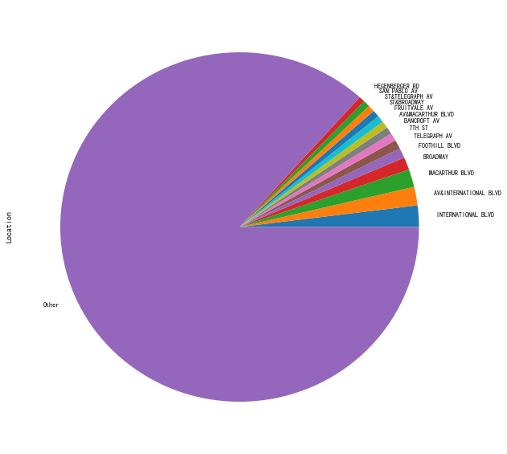

```python
plt.figure(figsize=(10,10))
loc_data = crime_data_merge["Location"]
# loc_list = []
# for i in range(len(loc_data)):
#     if len(loc_list) >= 10000:
#         print("Location : Too many items ! ")
#         break
#     if not loc_data[i] in loc_list:
#         loc_list.append(loc_data[i])
loc_list = loc_data.value_counts()
print("个数前十的地区名字有 ：")
loc_series = loc_list[0:14]
print(loc_series)

loc_series = loc_list[0:14]
loc_other = len(loc_data) - loc_series.sum()
loc_series.loc["Other"] = loc_other

# Convient for label
loc_series.plot.pie(fontsize=8)
plt.show()
```

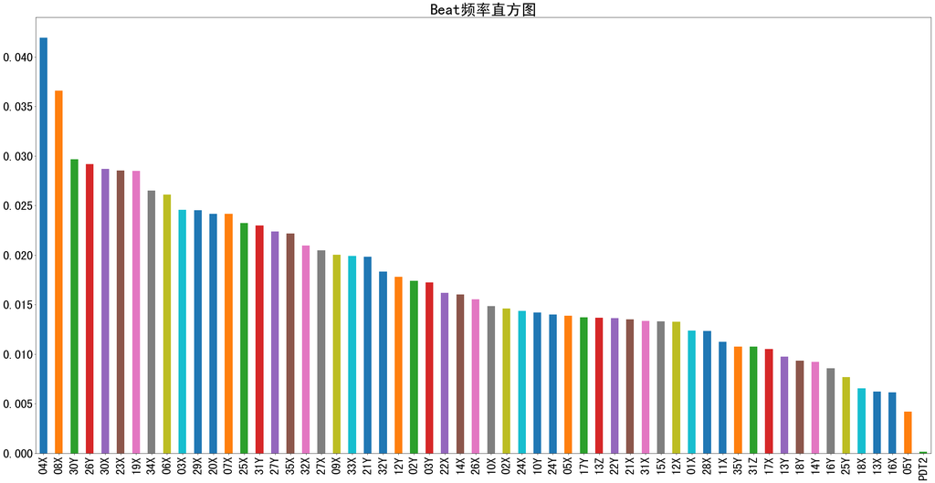

```python
plt.figure(figsize=(40,20))
crime_data_merge["Beat"].value_counts(normalize = True).plot.bar()
plt.title( "Beat频率直方图" , fontsize = 38 )
plt.xticks(fontsize=30)
plt.yticks(fontsize=30)
plt.show()
```

```
个数前十的Incident ID有 ：
933R     0.094131
SECCK    0.067819
415      0.063762
911H     0.052500
10851    0.045832
5150     0.035568
415C     0.031986
242      0.029278
912      0.025788
Name: Incident Type Id, dtype: float64
```

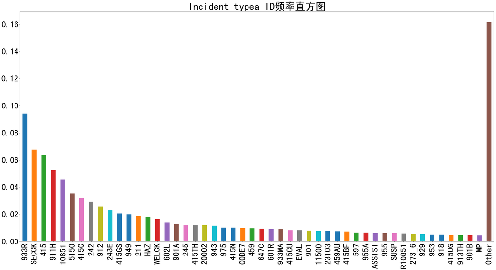

```python
plt.figure(figsize=(40,20))
Id_data = crime_data_merge["Incident Type Id"].value_counts(dropna = True , normalize = True)
Id_list = Id_data[0:9]

print("个数前十的Incident ID有 ：")
print(Id_list)

Id_series = Id_data[0:49]
Id_other = 1 - Id_series.sum()
Id_series.loc["Other"] = Id_other
# print(Id_series)

Id_series.plot.bar(fontsize=10)
plt.title( "Incident typea ID频率直方图" , fontsize = 48 )
plt.xticks(fontsize=40)
plt.yticks(fontsize=40)
plt.show()
```

```
2.0    814818
1.0    231542
0.0        24
Name: Priority, dtype: int64
```

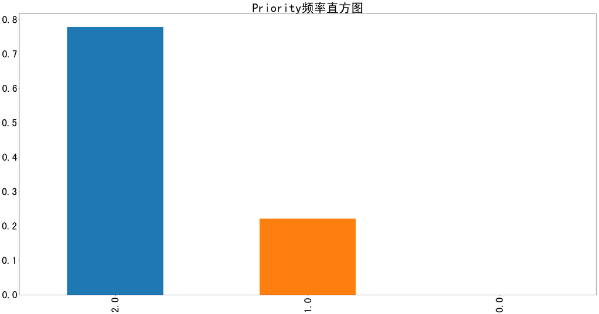

```python
plt.figure(figsize=(40,20))
print(crime_data_merge["Priority"].value_counts())
crime_data_merge["Priority"].value_counts(normalize = True).plot.bar()
plt.title( "Priority频率直方图" , fontsize = 48 )
plt.xticks(fontsize=40)
plt.yticks(fontsize=40)
plt.show()
```

**对于数值数据进行分析如下：**  
Create Time和Closed Time: 对于该数据做起五线图没什么意义，仅对其做时间分布的分布处理:包括发生日期，发生时段与持续时间(在第三部分补充完缺省值后再进行统计)。

```
统计日期内发生事件数：
2011-01-01    500
2011-01-02    381
2011-01-03    461
2011-01-04    409
2011-01-05    479
2011-01-06    425
2011-01-07    447
2011-01-08    459
2011-01-09    446
2011-01-10    449
Name: Create Time, dtype: int64
```

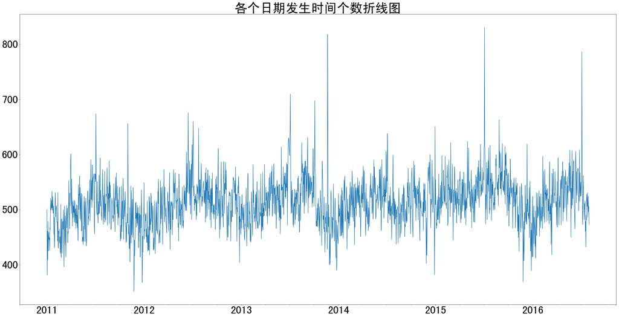

```python
# print(crime_data_merge["Create Time"])
day_dis = crime_data_merge["Create Time"]
day_distribution = day_dis.map(lambda i : i[0:10])
day_distribution = pd.to_datetime(day_distribution,format="%Y-%m-%d")
day_ = day_distribution.value_counts(sort = False , normalize = False)
day_ = day_.sort_index()
print("统计日期内发生事件数：")
print(day_[:10])

plt.figure(figsize=(40,20))
day_.plot(kind = "line")
plt.title( "各个日期发生时间个数折线图" , fontsize = 48 )
plt.xticks(fontsize=40)
plt.yticks(fontsize=40)
plt.show()
```

```
统计每天时刻中内发生事件数(单位：min)：
00:00    1429
00:01     702
00:02     690
00:03     778
00:04     682
00:05     701
00:06     753
00:07     731
00:08     730
00:09     708
Name: Create Time, dtype: int64
```

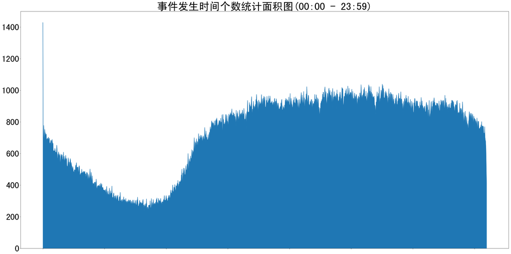

```python
time_distribution = day_dis.map(lambda i : i[-12:-7])
time_ = time_distribution.value_counts(sort = False , normalize = False)
time_ = time_.sort_index()
print("统计每天时刻中内发生事件数(单位：min)：")
print(time_[:10])
plt.figure(figsize=(40,20))
time_.plot(kind = "area")
plt.title( "事件发生时间个数统计面积图(00:00 - 23:59)" , fontsize = 48 )
plt.xticks(fontsize=40)
plt.yticks(fontsize=40)
plt.show()
```

**缺省值的补充**:  
首先查找数据发现主要的缺省位于：Area Id \ Beat \ Closed Time \ Closed Time, 数据的缺省可能有很多种，包括爬虫的失误或者是本身数据记录的不足，下面主要对前面三个进行缺省值的补充。

```python
print(crime_data_merge.isnull().any())

print(len(crime_data_merge["Beat"]) - len(crime_data_merge["Beat"].dropna()))
```

```
Agency                       False
Area Id                       True
Beat                          True
Closed Time                   True
Create Time                  False
Event Number                 False
Incident Type Description     True
Incident Type Id             False
Location                     False
Priority                     False
dtype: bool
5801
```

**Area id** :  
A. 将缺失部分剔除  
B. 用最高频率值来填补缺失值  
C. 通过属性的相关关系来填补缺失值(非数值数据：忽略)  
D. 通过数据对象之间的相似性来填补缺失值(相同地区的记录项的Id应当相同)

```python
Area_ID = crime_data_merge["Area Id"]
Area_ID_A = Area_ID.dropna()
print("NaN个数 ：" , len(Area_ID) - len(Area_ID_A))
# print(Area_ID.value_counts())  #查看最高频次的行名
Area_ID_B = Area_ID.fillna("P1")
# print(Area_ID_B.value_counts())

# 利用Loc关系进行填补

Area_ID_D_ = crime_data_merge.copy()
Area_ID_D_.sort_values("Location" , inplace = True)
Area_ID_D = Area_ID_D_["Area Id"]

index_area = np.where(Area_ID_D.isnull().values==True)
while(len(index_area[0]) > 0):
    Area_ID_D[index_area[0]] = Area_ID_D[index_area[0] - 1]
    index_area = np.where(Area_ID_D.isnull().values==True)
print(Area_ID_D.value_counts()[:3])
```

```
NaN个数 ： 182361
```

```
P1    489391
P2    351038
P3    196925
Name: Area Id, dtype: int64
```

```
Mathod A:
P1    405012
P2    289733
P3    161961
Name: Area Id, dtype: int64
Mathod B:
P1    587373
P2    289733
P3    161961
Name: Area Id, dtype: int64
Mathod D:
P1    489391
P2    351038
P3    196925
Name: Area Id, dtype: int64
```

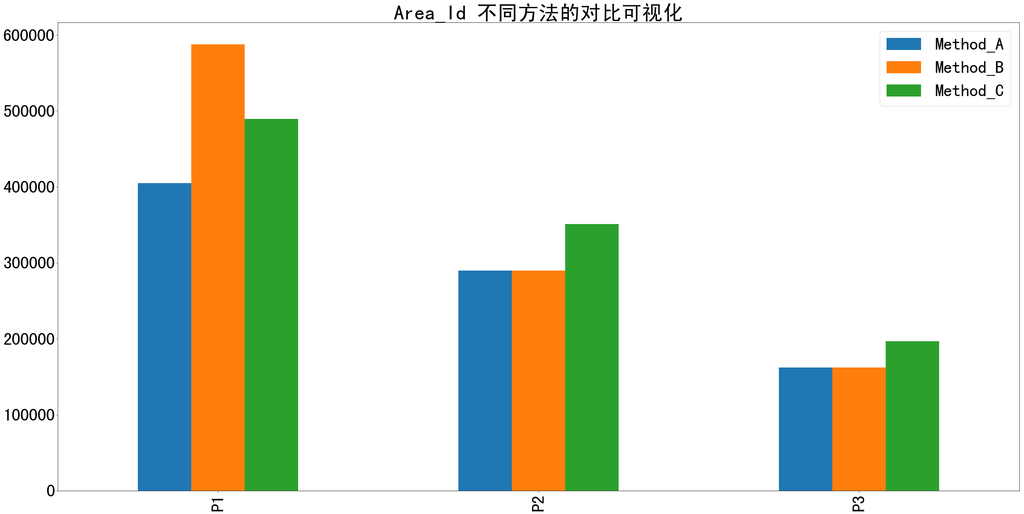

```python
Area_plot_A = Area_ID_A.value_counts()[:3]
print("Mathod A:")
print(Area_plot_A)
Area_plot_B = Area_ID_B.value_counts()[:3]
print("Mathod B:")
print(Area_plot_B)
Area_plot_D = Area_ID_D.value_counts()[:3]
print("Mathod D:")
print(Area_plot_D)
Area_plot = pd.DataFrame(list(zip(Area_plot_A,Area_plot_B,Area_plot_D)),columns=['Method_A', 'Method_B',"Method_C"],index=["P1","P2","P3"])
Area_plot.plot(kind='bar',figsize=(40,20))
plt.title( "Area_Id 不同方法的对比可视化" , fontsize = 48 )
plt.xticks(fontsize=40)
plt.yticks(fontsize=40)
plt.legend(fontsize = 40)
plt.show()
```

**Beat :**  
对该项没有关联项，因此仅仅作前两项处理

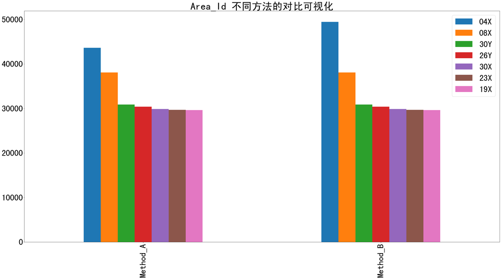

```python
Beat_ = crime_data_merge["Beat"]
Beat_A = Beat_.dropna()

# print(Beat_.value_counts()[:1])  #查看最高频次的行名
Beat_B = Beat_.fillna("04X")

Area_plot = pd.DataFrame(list(zip(Beat_A.value_counts()[:7],Beat_B.value_counts()[:7])),columns=['Method_A', 'Method_B'],index=Beat_A.value_counts()[:7].index)
Area_plot = Area_plot.T
Area_plot.plot(kind='bar',figsize=(40,20))
plt.title( "Area_Id 不同方法的对比可视化" , fontsize = 48 )
plt.xticks(fontsize=40)
plt.yticks(fontsize=40)
plt.legend(fontsize = 40)
plt.show()
```

**因为是时间数据，因而最终拟合与可视化的媒介都表现为持续时间。**  
同时 因为缺失值太少补全后影响太小 故仅仅对补充的值单独进行可视化。

```python
Closed_time = crime_data_merge["Closed Time"]
print("NaN个数 ：" , len(Closed_time) - len(Closed_time.dropna()))
Closed_nan_index = np.where(Closed_time.isnull().values==True)
Start_ = crime_data_merge["Create Time"][Closed_nan_index[0]]  #对应于缺失的Create time
# print(Closed_nan_index[0])

#Method A
time_A_ = crime_data_merge.copy().reset_index(drop=True)
time_A_ = time_A_.drop(index = Closed_nan_index[0].tolist())
time_A_start = time_A_["Create Time"]
time_A_end = time_A_["Closed Time"]
A_start = time_A_start.map(lambda i : str(i)[:10] +'-' + str(i)[-12:-4])
A_start = pd.to_datetime(A_start,format="%Y-%m-%d-%H:%M:%S")
A_end = time_A_end.map(lambda i : str(i)[:10] +'-' + str(i)[-12:-4])
A_end = pd.to_datetime(A_end,format="%Y-%m-%d-%H:%M:%S")
A_con = A_end - A_start
A_con = A_con.map(lambda x: x/np.timedelta64(1,'m'))   # 时间持续时间
```

```
NaN个数 ： 25
```

```python
#Method B
time_B_ = crime_data_merge.copy()["Closed Time"].reset_index(drop=True)
time_B_ = time_B_.drop(index = Closed_nan_index[0].tolist())
Aver_B_end = time_B_.map(lambda i : str(i)[-12:-4])
Aver_B = pd.to_datetime(Aver_B_end ,format="%H:%M:%S")
# print(Aver_B.value_counts()) # 23:42:37    35 次
B_start = pd.to_datetime(Start_.map(lambda i : str(i)[-12:-4]),format="%H:%M:%S")
# print(B_start)
B_con = (pd.to_datetime("23:42:37" ,format="%H:%M:%S" ) - B_start).map(lambda x: x/np.timedelta64(1,'m'))
# print(B_con)
for i in range(0,len(B_con)):
    if B_con[i] < 0 :
        B_con[i] = B_con[i] + 24 * 60
# print(B_con)
```

```python
cltime_D = crime_data_merge.copy()["Closed Time"].reset_index(drop=True)
crtime_D = crime_data_merge.copy()["Create Time"].reset_index(drop=True)
priority_D = crime_data_merge.copy()["Priority"].reset_index(drop=True)
time_series = pd.DataFrame(list(zip(cltime_D , crtime_D , priority_D )),columns=["Closed Time" , "Create Time","Priority"])
time_series = time_series.reset_index(drop=True)

time_series_base = time_series.dropna()
time_series_drop_index = np.where(cltime_D.isnull().values==True)[0]
time_series_drop = pd.DataFrame(list(zip(crtime_D[time_series_drop_index] , cltime_D[time_series_drop_index] , priority_D[time_series_drop_index])),columns=["Closed Time" , "Create Time","Priority"])
base_start = time_series_base["Create Time"].map(lambda i : str(i)[:10] +'-' + str(i)[-12:-4])
base_start = pd.to_datetime(base_start ,format="%Y-%m-%d-%H:%M:%S")

base_end = time_series_base["Closed Time"].map(lambda i : str(i)[:10] +'-' + str(i)[-12:-4])
base_end = pd.to_datetime(base_end ,format="%Y-%m-%d-%H:%M:%S")

con_base = base_end - base_start
con_base = con_base.map(lambda x: x/np.timedelta64(1,'m'))

model_crime = LinearRegression()
model_crime.fit(time_series_base["Priority"].values.reshape(-1, 1), con_base.values.reshape(-1, 1))
print("拟合的表达式为：%.4f * x + (%.4f) + e " %(model_crime.coef_,model_crime.intercept_) )
con_fit = model_crime.predict(time_series_drop["Priority"].values.reshape(-1,1))
D_con = con_fit.reshape(-1)
```

```
拟合的表达式为：-50.4815 * x + (290.9791) + e
```

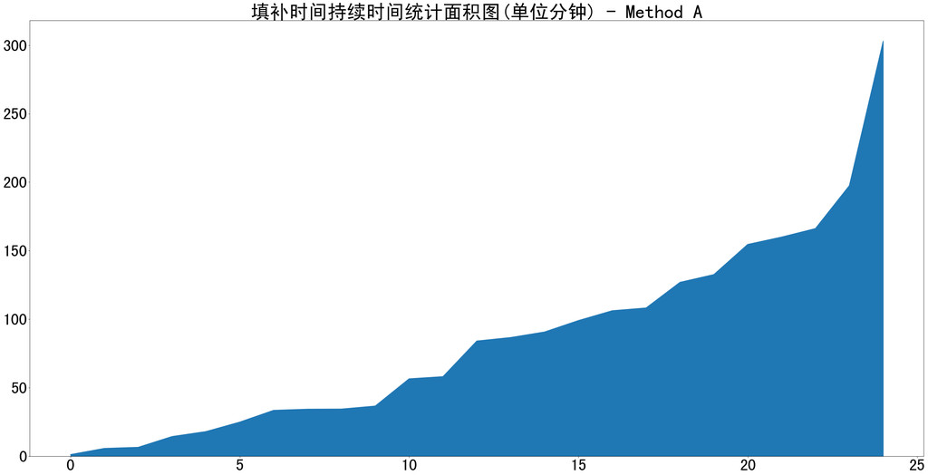

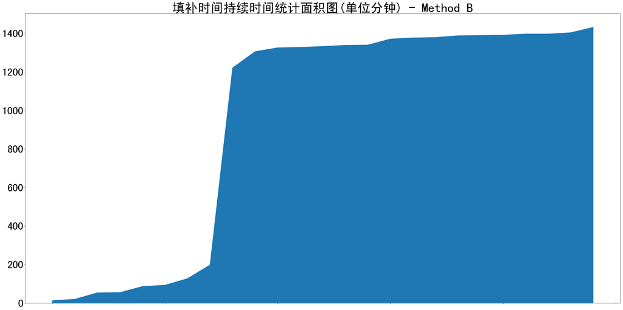

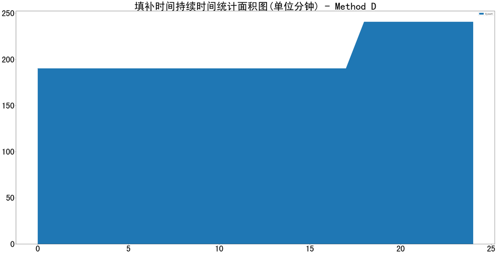

```python
A_count = A_con.sample(len(B_con)).sort_values().reset_index(drop=True)

plt.figure(figsize=(40,20))
A_count.plot(kind = "area")
plt.title( "填补时间持续时间统计面积图(单位分钟) - Method A" , fontsize = 48 )
plt.xticks(fontsize=40)
plt.yticks(fontsize=40)
plt.show()

B_count = B_con.sort_values()
plt.figure(figsize=(40,20))
# print(B_count)
B_count.plot(kind = "area")
plt.title( "填补时间持续时间统计面积图(单位分钟) - Method B" , fontsize = 48 )
plt.xticks(fontsize=40)
# plt.xlim([1330,1400])
plt.yticks(fontsize=40)
plt.show()

plt.figure(figsize=(40,20))
D_count = pd.DataFrame(D_con,columns=["D_count"]).reset_index(drop=True)
D_count = D_count.sort_values("D_count").reset_index(drop=True)
# print(D_count)
D_count.plot(kind = "area",figsize=(40,20))
plt.title( "填补时间持续时间统计面积图(单位分钟) - Method D" , fontsize = 48 )
plt.xticks(fontsize=40)
plt.yticks(fontsize=40)
plt.show()
```

### 3. 处理数据集 - Wine Reviews

**数据集分析** ：  
该数据集是对于葡萄酒的品鉴结果收集集,两个数据集中记载了130k与150k的葡萄酒品鉴评论,其中第二个数据集为作者后来重新爬取的结果，这次爬取中作者额外收集了每个评论的标题、年份、品酒者的姓名和品酒者的Twitter句柄，并解决了重复输入的问题，因此这里主要处理的是winemag-data-130k-v2.csv,另一个表仅作绘图时的参考。该数据集中属性包含有：country \ description \ designation \ points \ price \ province \ region_1 \ region_2 \ taster_name \ taster_twitter_handle \ title \ variety \ winery, 并给出了各个属性的描述。

```python
data_dir_cbd = r"F:\course\web\data\wine-reviews"
cdb_data_main = pd.read_csv(data_dir_cbd + "\winemag-data-130k-v2.csv")
cdb_data_old = pd.read_csv(data_dir_cbd + "\winemag-data_first150k.csv")
# print(cdb_data.head())
```

**数据可视化和摘要** :  
**标称属性:** Country \ Designation \ Province \ Region \ variety \ winery等，其中部分例如推特评论账号等因为分类过多，因此不作其对应的频度直方图。  
**数值属性:** 主要是Points与Price属性。

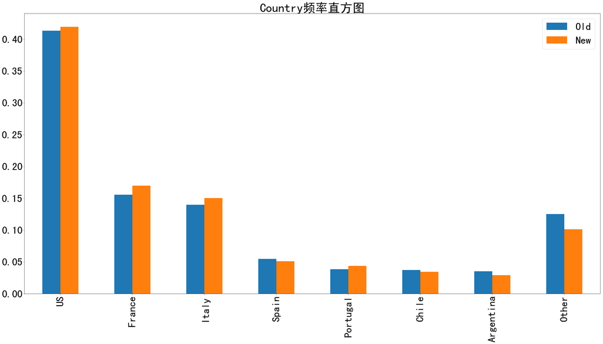

```python
Country_series = cdb_data_main["country"].value_counts(normalize = True)
# print(Country_series)
Country_series_ = Country_series[:7]
Country_other = 1 - Country_series_.sum()
Country_series_.loc["Other"] = Country_other

old_Country_series = cdb_data_old["country"].value_counts(normalize = True) # print(Country_series)
old_Country_series_ = old_Country_series[:7]
old_Country_other = 1 - old_Country_series_.sum()
old_Country_series_.loc["Other"] = old_Country_other
C_Country_series = pd.DataFrame(list(zip(old_Country_series_,Country_series_)),columns=['Old', 'New'],index=Country_series_.index)
C_Country_series.plot.bar(figsize=(40,20), fontsize=10)
plt.title( "Country频率直方图" , fontsize = 48 )
plt.xticks(fontsize=40)
plt.yticks(fontsize=40)
plt.legend(fontsize=40)
plt.show()
```

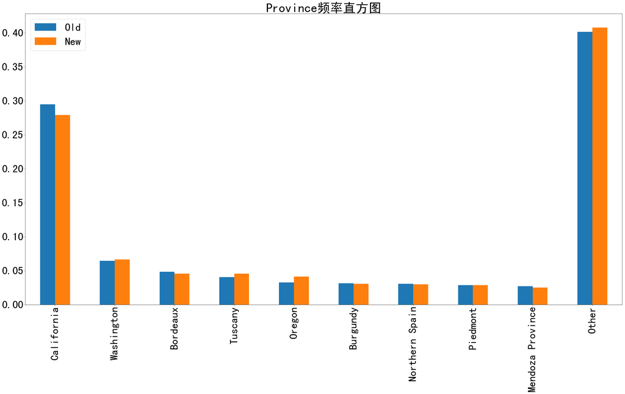

```python
# # designation 过小
# designation = cdb_data_main["designation"].value_counts(normalize = True)
# print(designation , len(designation))

# province
province = cdb_data_main["province"].value_counts(normalize = True)
province_ = province[:9]
province_other = 1 - province_.sum()
province_.loc["Other"] = province_other

province_old = cdb_data_old["province"].value_counts(normalize = True)
province_old_ = province_old[:9]
province_old_other = 1 - province_old_.sum()
province_old_.loc["Other"] = province_old_other

C_province = pd.DataFrame(list(zip(province_old_,province_)),columns=['Old', 'New'],index=province_.index)
C_province.plot.bar(figsize=(40,20), fontsize=10)
plt.title( "Province频率直方图" , fontsize = 48 )
plt.xticks(fontsize=40)
plt.yticks(fontsize=40)
plt.legend(fontsize=40)
plt.show()
```

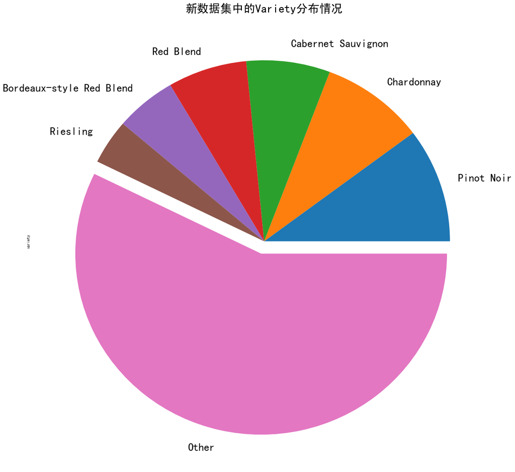

```python
# # region_1
# region_1 = cdb_data_main["region_1"].value_counts(normalize = True)
# print(region_1 , len(region_1))

# variety
variety = cdb_data_main["variety"].value_counts(normalize = True)
variety_ = variety[:6]
variety_other = 1 - variety_.sum()
variety_.loc["Other"] = variety_other

plt.figure(figsize=(20,20))
variety_.plot.pie(explode = [0,0,0,0,0,0,0.07] , fontsize=26)
plt.title("新数据集中的Variety分布情况",fontsize = 28)
plt.show()
```

```
Points缺失个数为： 0
Points五数概括为： 80 86.0 88.0 91.0 100
```

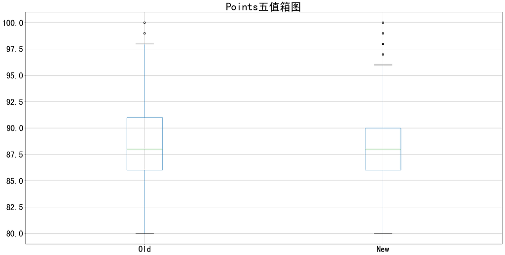

```python
# # winery
# winery = cdb_data_main["winery"].value_counts(normalize = True)
# print(winery , len(winery))

# # 数值数据分析
# points
points = cdb_data_main["points"]
points_old = cdb_data_old["points"]
print("Points缺失个数为：" , len(points) - len(points.dropna()))
print("Points五数概括为：" , min(points) ,np.percentile(points,25) ,np.median(points) ,np.percentile(points,75) , max(points))
C_points = pd.DataFrame(list(zip(points,points_old)),columns=['Old', 'New'])
# C_points.boxplot(figsize=(40,20), fontsize=10  , linewidth=1)
C_points.plot.box(figsize=(30,15), fontsize=14 ,grid = True)
plt.title( "Points五值箱图" , fontsize = 38 )
plt.xticks(fontsize=30)
plt.yticks(fontsize=30)
plt.show()
```

```
Price缺失个数为： 8996
Price五数概括为： 4.0 17.0 25.0 42.0 3300.0
```

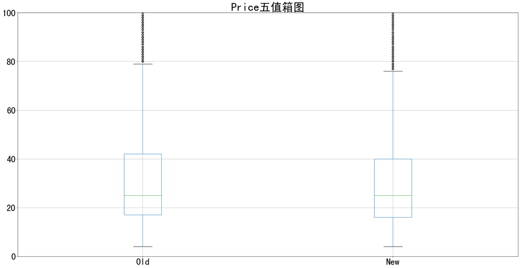

```python
# price
price = cdb_data_main["price"]
price_old = cdb_data_old["price"]
print("Price缺失个数为：" , len(price) - len(price.dropna()))
price_ = price.dropna()
print("Price五数概括为：" , min(price_) ,np.percentile(price_,25) ,np.median(price_) ,np.percentile(price_,75) , max(price_))
C_price = pd.DataFrame(list(zip(price,price_old)),columns=['Old', 'New'])
# C_points.boxplot(figsize=(40,20), fontsize=10  , linewidth=1)
C_price.plot.box(figsize=(30,15), fontsize=14 ,grid = True)
plt.title( "Price五值箱图" , fontsize=38)
plt.ylim([0,100])
plt.xticks(fontsize=30)
plt.yticks(fontsize=30)
plt.show()
```

```python
# price
price_A = price.dropna()

# print(price.value_counts(dropna = True)) #20.0      6940
price_B = price.fillna(20)

# 相关关系 price - points
pp_corr = pd.DataFrame(list(zip(points,price)),columns = ['points' , 'price'])
print("Price 与 Points相关性矩阵为：")
print(pp_corr.corr("spearman"))
# 拟合
pp_corr_drop = pp_corr.dropna()
model = LinearRegression()
model.fit(pp_corr_drop["points"].values.reshape(-1, 1), pp_corr_drop["price"].values.reshape(-1, 1))
print("拟合的表达式为：%.4f * x + (%.4f) + e " %(model.coef_,model.intercept_) )
price_fit = model.predict(points.values.reshape(-1,1))
price_fit = price_fit.reshape(-1)
new_pp = pd.DataFrame(list(zip(price,price_fit)),columns = ['price' , 'price_fit'])
price_C = new_pp.price.combine_first(new_pp.price_fit)
print("C方法处理之后NaN个数 ：" , len(price_C) - len(price_C.dropna()))

# 相似性 (先找Varity 再找designation)
price_D = price.copy()
price_nan_index = np.where(price.isnull().values==True)[0]
variety_D = cdb_data_main["variety"]
designation_D = cdb_data_main["designation"]
for i in price_nan_index:
    variety_i = variety_D[i]
    designation_i = designation_D[i]
    v_poss = np.where(variety_D == variety_i)
    d_poss = np.where(designation_D == designation_i)
    and_index = list(set(v_poss[0]) & set(d_poss[0]) - set(list(price_nan_index)))
    if and_index != []:
        k = random.sample(and_index , 1)
        price_D[i] = price_D[k]
        continue
    v_index = list(set(v_poss[0]) - set(list(price_nan_index)))
    if v_index != []:
        k = random.sample(v_index , 1)
        price_D[i] = price_D[k]
        continue
    d_index = list(set(d_poss[0]) - set(list(price_nan_index)))
    if d_index != []:
        k = random.sample(d_index , 1)
        price_D[i] = price_D[k]
        continue
    ran_index = list(set(np.arange(0,len(price_D))) - set(list(price_nan_index)))
    k = random.sample(ran_index , 1)
    price_D[i] = price_D[k]
print("D方法处理之后NaN个数 ：" ,len(price_D) - len(price_D.dropna()))
```

```
Price 与 Points相关性矩阵为：
          points     price
points  1.000000  0.605785
price   0.605785  1.000000
拟合的表达式为：5.6075 * x + (-460.4624) + e
C方法处理之后NaN个数 ： 0
D方法处理之后NaN个数 ： 0
```

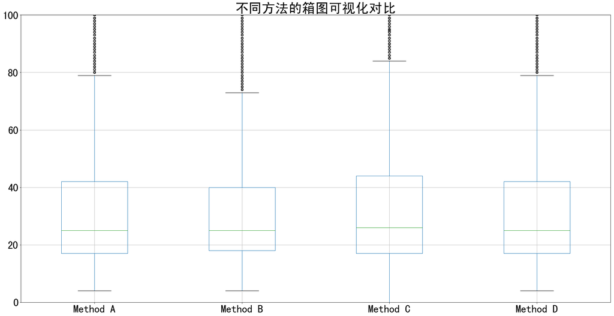

```python
Method_price = pd.DataFrame(list(zip(price_A,price_B,price_C,price_D)),columns=['Method A', 'Method B','Method C', 'Method D'])
Method_price.plot.box(figsize=(30,15), fontsize=14 ,grid = True)
plt.title( "不同方法的箱图可视化对比" , fontsize=38)
plt.xticks(fontsize=30)
plt.yticks(fontsize=30)
plt.ylim([0,100])
plt.show()
```

**Github:** https://github.com/FadedFate/Data_Homework